# DATA 606 Homework 5

Ilya Kats

April 1, 2017

### 5.6 Working bakwards, Part II.

90% confidence interval is (65, 77), n = 25, df = 24

The sample mean is midpoint in the confidence interval, $\bar{x} = \frac{65+77}{2} = 71$.

Margin of error is $ME = 77-71 = 6$.

```r
t24 <- qt(0.95, df=24)
t24
```

```
## [1] 1.710882
```

$ME = t_{24}^* SE$, so $SE = \frac{ME}{t_{24}^*} = \frac{s}{\sqrt{n}}$

$s = \frac{ME\sqrt{n}}{t_{24}^*} = \frac{6 * \sqrt{25}}{1.71088} = 17.53481$

**ANSWER:**

$\bar{x} = 71, ME = 6, s = 17.53481$

### 5.14 SAT scores.

$\sigma = 250, ME = 25$

### 5.20 High School and Beyond, Part I.

$n = 200$

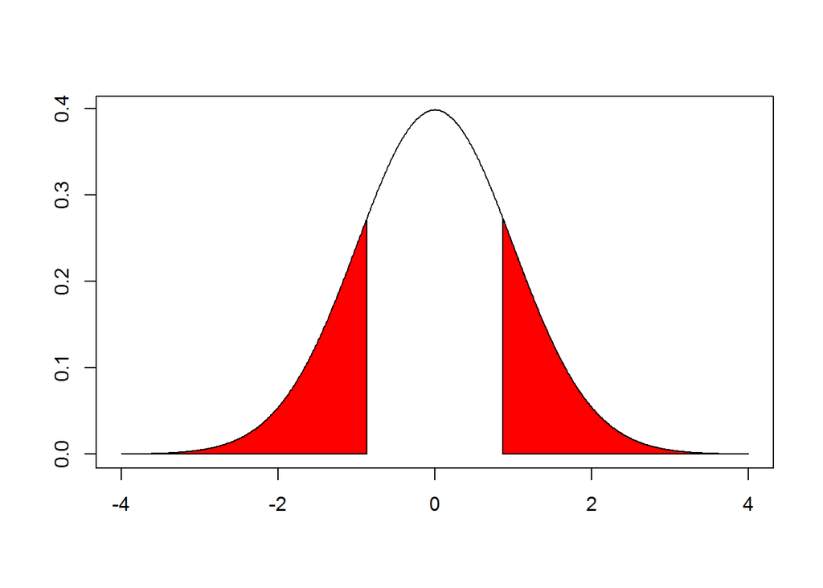

```r
plot(seq(-4, 4, 0.01), dt(seq(-4, 4, 0.01), df=199), type="l", xlab = "", ylab = "")
polygon(c(-4, seq(-4, -0.867, 0.01), -0.867),
        c(0, dt(seq(-4, -0.867, 0.01), df = 199), 0),
        col = "red")
polygon(c(0.867, seq(0.867, 4, 0.01), 4),
        c(0, dt(seq(0.867, 4, 0.01), df = 199), 0),
        col = "red")
```

```r
# Calculate p-value
pt(-0.867282, df=199) * 2
```

```
## [1] 0.3868321
```

Assuming 95% confidence interval, $\alpha = 0.05$, since $p-value = 0.3868 > 0.05$, we fail to reject $H_0$. This sample **does not provide convincing evidence** of a difference between reading and writing scores.

6. **Type II error** is possible, since we might have incorrectly failed to reject the null hypothesis.
7. We have failed to reject the null hypothesis which included the value of 0, so we would expect a confidence interval to include 0.

### 5.32 Fuel efficiency of manual and automatic cars, Part I.

$\bar{x}_{automatic} = 16.12, \bar{x}_{manual} = 19.85$

$s_{automatic} = 3.58, s_{manual} = 4.51$

$n_{automatic} = n_{manual} = n = 26$

$H_0: \mu_{automatic} - \mu_{manual} = 0$  
$H_A: \mu_{automatic} - \mu_{manual} \ne 0$

$\bar{x}_{automatic} - \bar{x}_{manual} = 16.12 - 19.85 = -3.73$

$SE = \sqrt{\frac{s_{automatic}^2}{n}+\frac{s_{manual}^2}{n}} = \sqrt{\frac{3.58^2}{26}+\frac{4.51^2}{26}} = 1.12927$

$df = 25$

$T = \frac{-3.73-0}{1.12927} \approx -3.303$

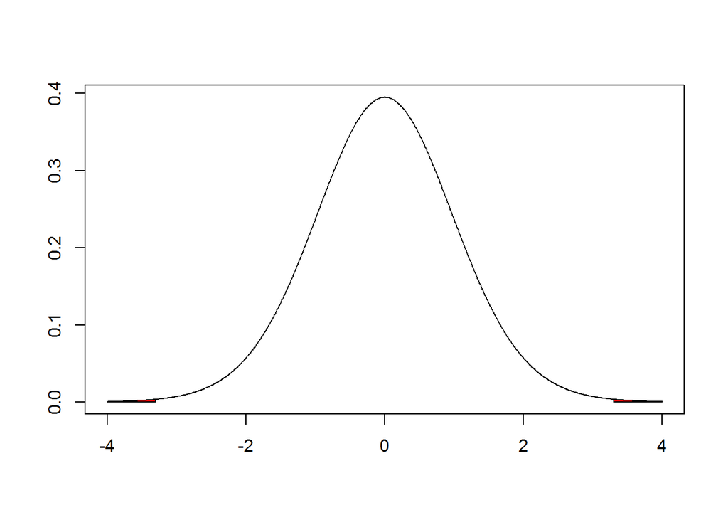

```r
plot(seq(-4, 4, 0.01), dt(seq(-4, 4, 0.01), df=25), type="l", xlab = "", ylab = "")
polygon(c(-4, seq(-4, -3.303, 0.01), -3.303),
        c(0, dt(seq(-4, -3.303, 0.01), df = 25), 0),
        col = "red")
polygon(c(3.303, seq(3.303, 4, 0.01), 4),
        c(0, dt(seq(3.303, 4, 0.01), df = 25), 0),
        col = "red")
```

```r
# Calculate p-value
pt(-3.303, df=25) * 2
```

```
## [1] 0.002883755
```

Assume confidence interval of 95%, $\alpha = 0.05$. Since $p-value = 0.003 < 0.05$, we reject $H_0$. The difference in average fuel efficiency of cars with automatic and manual transmissions is not due to chance.

### 5.48 Works hours and education.

1. $H_0$: Average number of hours worked is the same for all groups.  
   $H_A$: Average number of hours worked varies for some (or all) groups.
2. We have to assume that the respondents were selected for the survey randomly. 1,172 observations clearly comprise less than 10% of population, so we can **assume independence within each group and across all groups**. Box plots for all groups appear symmetrical. There are outliers for some groups, but considering a relatively large sample, we can assume that the **distribution is normal**. Box plots and mean and SD value are somewhat similar between groups, so **variability is about equal**.
3. Assume confidence interval of 95%, $\alpha = 0.05$. Since $p-value = 0.0682 > \alpha$, we fail to reject $H_0$.

```r
# Store given values
k <- 5
n <- 1172
MSG <- 501.54
SSE <- 267382
p <- 0.0682

# Find Df
dfG <- k-1
dfE <- n-k
dfT <- dfG + dfE
df <- c(dfG, dfE, dfT)

# Find Sum Sq
SSG <- dfG * MSG
SST <- SSG + SSE
SS <- c(SSG, SSE, SST)

# Find Mean Sq
MSE <- SSE / dfE
MS <- c(MSG, MSE, NA)

# Find F-value
Fv <- MSG / MSE

# Combine all values and display
annovatb <- data.frame(df, SS, MS, c(Fv, NA, NA), c(p, NA, NA))
colnames(annovatb) <- c("Df", "Sum Sq", "Mean Sq", "F Value", "Pr(>F)")
rownames(annovatb) <- c("degree", "Residuals", "Total")

annovatb
```

```
##             Df    Sum Sq  Mean Sq  F Value Pr(>F)
## degree       4   2006.16 501.5400 2.188992 0.0682
## Residuals 1167 267382.00 229.1191       NA     NA
## Total     1171 269388.16       NA       NA     NA
```